#### Procesamiento Digital de Señales

# Trabajo Práctico 1

## Muestreo de señales - Fourier

**1)** Se busca realizar una librería en Python que nos permita obtener $N$ muestras de las siguientes señales de período $T_0=1/f_0$, muestreadas a una frecuencia $f_s$ :

- **Senoidal**

> $s(k)=A_0.sin(2\pi.k.\frac{ f_0}{f_s} + \phi_0),\space\space \forall k \in \Bbb{R} \wedge k \in (0, N-1)$
- **Ruido** incorrelado de distribución Gaussiana y parámetros $\mu$ y $\sigma^2$
- (Opcional) **Cuadrada** con ciclo de actividad $d \in (0,1)$

> $s(k)=A_0,\space\space \forall k \in (0, N.d ]$

> $s(k)=-A_0,\space \forall k \in (N.d, N-1)$
- (Opcional) **Triangular** con punto de simetría $d \in (0,1)$ y coeficientes $a_{ij} \in \Bbb{R}$

> $s(k)=a_{11}.k/f_s+a_{12},\space\space \forall k \in (0, N.d ]$

> $s(k)=a_{21}.k/f_s+a_{22},\space \forall k \in (N.d, N-1)$

Es decir que se podría invocar la señal que genere la senoidal de la siguiente manera:

```python
def mySignalGenerator (sType ='sin',param =(1, 1) ,fs = 1000, N = 1000, optionalParam=(0, 0)):
    Ts = 1/fs
    t = np.arange(0, N*Ts, Ts)

    if sType == 'sin':
        # Senoidal (fo=1, Ao=1)
        # optionalParam (phi=0, dc=0)
        #print("Senoidal")
        fo = param[0]
        Ao = param[1]
        phi = optionalParam[0]
        dc = optionalParam[1]

        f = Ao * (np.sin(2 * np.pi * fo * t + phi)) + dc
        return t,f

    elif sType == 'n':
        # Ruido blanco (u,std)
        # optionalParam (none,none)
        #print("White Noise")
        u = param[0]
        std = param[1]
        f = np.random.normal(u, std, size=N)
        return t, f


    elif sType == 't':
        # Triangular (To, Ao)
        # optionalParam (none,none)
        #print("Triangular")
        To = param[0]
        Ao = param[1]
        f = Ao/2 * signal.sawtooth(2 * np.pi * 1/To * t) + Ao/2
        return t, f

    elif sType == 'sq':
        # Cuadrada (To, Ao)
        # optionalParam = (none, none)
        #print("Square")
        To = param[0]
        Ao = param[1]
        f = Ao/2 * signal.square(2 * np.pi * 1/To *t) + Ao/2


        return t, f

    else:
        raise ValueError("El argumento sType debe ser 'sin','n','t' o 'sq'.")
```

a) Genere las gráficas asociadas a las siguientes señales de ejemplo para corroborar el correcto funcionamiento de las funciones. Para la presentación de las mismas, tome como referencia la presentación de la siguiente señal respecto a:

- etiquetas indicando cada eje con sus respectivas unidades
- leyendas indicando cada trazo o color qué representa
- título de la figura que explique lo que se pretende visualizar

[figure not shown]

```python
# Módulos del programa
import numpy as np
import matplotlib as mpl
import matplotlib.pyplot as plt
import scipy.signal as signal
# Módulos para Jupyter
import warnings
warnings.filterwarnings('ignore')

# Insertar aquí el código para inicializar tu notebook
########################################################
```

```python
# NO modifiques este bloque
############################

N  = 1000 # muestras
fs = 1000 # Hz
W = fs / (N) #Resolución espectral
```

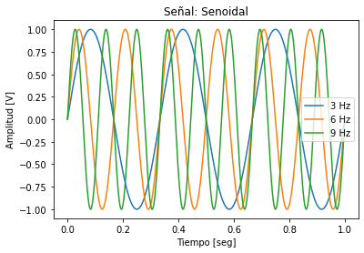

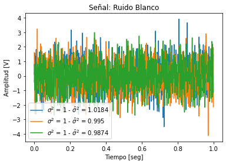

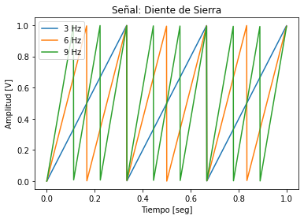

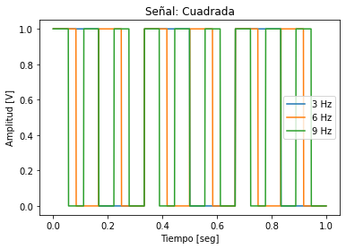

```python
##############################################
# En esta celda evaluo el generador de señales
##############################################
# Senoidal
t1,f1 = mySignalGenerator ('sin',(3, 1) ,fs, N, (0, 0));
t2,f2 = mySignalGenerator ('sin',(6, 1) ,fs, N, (0, 0));
t3,f3 = mySignalGenerator ('sin',(9, 1) ,fs, N, (0, 0));
# Ruido
t4,f4 = mySignalGenerator ('n',(0, 1) ,fs, N, (0, 0));
t5,f5 = mySignalGenerator ('n',(0, 1) ,fs, N, (0, 0));
t6,f6 = mySignalGenerator ('n',(0, 1) ,fs, N, (0, 0));
# Cuadrada
t7,f7 = mySignalGenerator ('t',(1/3, 1) ,fs, N, (0, 0));
t8,f8 = mySignalGenerator ('t',(1/6, 1) ,fs, N, (0, 0));
t9,f9 = mySignalGenerator ('t',(1/9, 1) ,fs, N, (0, 0));
# Diente de Sierra
t10,f10 = mySignalGenerator ('sq',(1/3, 1) ,fs, N, (0, 0));
t11,f11 = mySignalGenerator ('sq',(1/6, 1) ,fs, N, (0, 0));
t12,f12 = mySignalGenerator ('sq',(1/9, 1) ,fs, N, (0, 0));

# Graficamos
# Senoidal
fig, ax1 = plt.subplots(1,1)
ax1.plot(t1, f1, label='3 Hz')
ax1.plot(t2, f2, label='6 Hz')
ax1.plot(t3, f3, label='9 Hz')
ax1.set_xlabel('Tiempo [seg]')
ax1.set_ylabel('Amplitud [V]')
ax1.set_title("Señal: Senoidal")
ax1.legend()
# Ruido
fig, ax1 = plt.subplots(1,1)
ax1.plot(t4, f4, label= '$\sigma^2$ = 1 - $\hat{\sigma}^2$ = '+str( round( np.std(f4),4) ))
ax1.plot(t5, f5, label= '$\sigma^2$ = 1 - $\hat{\sigma}^2$ = '+str( round( np.std(f5),4) ))
ax1.plot(t6, f6, label= '$\sigma^2$ = 1 - $\hat{\sigma}^2$ = '+str( round( np.std(f6),4) ))
ax1.set_xlabel('Tiempo [seg]')
ax1.set_ylabel('Amplitud [V]')
ax1.set_title("Señal: Ruido Blanco")
ax1.legend()
# Diente de Sierra
fig, ax1 = plt.subplots(1,1)
ax1.plot(t7, f7, label='3 Hz')
ax1.plot(t8, f8, label='6 Hz')
ax1.plot(t9, f9, label='9 Hz')
ax1.set_xlabel('Tiempo [seg]')
ax1.set_ylabel('Amplitud [V]')
ax1.set_title("Señal: Diente de Sierra")
ax1.legend()
# Cuadrada
fig, ax1 = plt.subplots(1,1)
ax1.plot(t10, f10, label='3 Hz')
ax1.plot(t11, f11, label='6 Hz')
ax1.plot(t12, f12, label='9 Hz')
ax1.set_xlabel('Tiempo [seg]')
ax1.set_ylabel('Amplitud [V]')
ax1.set_title("Señal: Cuadrada")
ax1.legend()
```

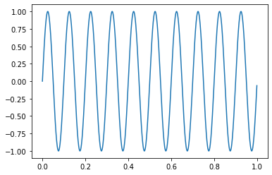

```python
##################
# a.1) Senoidal #
#################

a0 = 1 # Volts
p0 = 0 # radianes
f0 = 10   # Hz

# Insertar aquí el código para generar y visualizar la señal
##############################################################
t1,f1 = mySignalGenerator('sin', (f0, a0) ,fs ,N ,(p0, 0));
plt.plot(t1,f1)
```

¿Podría inferir la frecuencia de la senoidal a.1 a partir de su representación temporal?

**Respuesta:** Si. Para ello es necesario medir cual es el periodo, es decir cada cuanto se repite la señal.

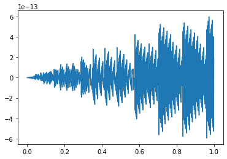

```python
##################
# a.2) Senoidal #
#################

a0 = 1 # Volts
p0 = 0 # radianes
f0 = fs/2# Hz

# Insertar aquí el código para generar y visualizar la señal
##############################################################
t2,f2 = mySignalGenerator('sin',(f0, a0) ,fs ,N ,(p0, 0));
plt.plot(t2,f2)
```

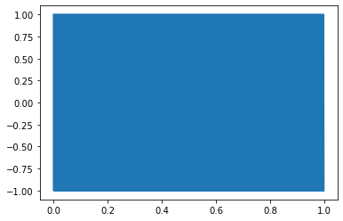

```python
##################
# a.3) Senoidal #
#################

a0 = 1       # Volts
p0 = np.pi/2 # radianes
f0 = fs/2    # Hz

# Insertar aquí el código para generar y visualizar la señal
##############################################################
t3,f3 = mySignalGenerator('sin',(f0, a0) ,fs ,N ,(p0, 0));
plt.plot(t3,f3)
```

¿Y para los casos **a.2** y **a.3** podría conocer los parámetros de la senoidal?

**Respuesta:** En estos casos no es posible calcularlos mediante el mismo método.

¿A qué se debe?

**Respuesta:** En ambos casos no es posible conocer nada sobre la función mediante el gráfico dado que la representación visual de la señal no es de fácil comprensión. En el primer caso, el fenómeno se da por estar trabajando sobre una señal que esta siendo muestreada con una frecuencia igual a la de Nysquit, y se trabaja con una fase nula. Esto tiene una implicancia negativa en la resolución a bajo nivel de la función, por ello se muestra esa señal en forma de arbolito. En el caso de la segunda señal, vemos que la señal solamente consta de picos y valles.

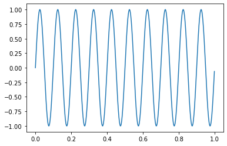

```python
##################
# a.4) Senoidal #
#################

a0 = 1     # Volts
p0 = 0     # radianes
f0 = fs +10 # Hz

# Insertar aquí el código para generar y visualizar la señal
##############################################################
t4,f4 = mySignalGenerator('sin',(f0, a0) ,fs ,N ,(p0, 0));
plt.plot(t4,f4)
```

¿Es posible diferenciar **a.1** de **a.4** a partir de las gráficas?

**Respuesta:** No podemos diferenciar estas señales en una grafica en función del tiempo. Esto se debe a que nosotros solo podemos visualizar valores que en el dominio frecuencial se encuentren entre $0$ y $f_{s}$. Ambas señales tienen una delta de Kronecker en $\omega = 10$, una debido a que es su frecuencia real (a.1) y la otra debido al efecto del muestreo (a.4).

¿En caso que no, qué solución podría implementar para evitar dicha ambigüedad?

**2.a)** (Opcional) Implemente un algoritmo que calcule la transformada discreta de Fourier (DFT). Utilice las funciones generadoras de señales de 1) para evaluar y ejemplificar su funcionamiento.

```python
def mi_analizador(f, N):

    k = np.arange(0,N).astype(int)      #Calculamos la base temporal discreta

    Fk = np.zeros(N).astype(complex)    #Generamos un vector vacio con la salida

    Wkn = np.zeros([k.size,k.size], dtype = complex)    #k va de 0 a N-1 y n lo mismo

    index = 0
    for kloop in k:
        Wkn[:,kloop] = np.exp( -1j * (2*np.pi/N) * kloop * k)
        index += 1

    Fk = np.matmul(Wkn,f)

    return k, Fk
```

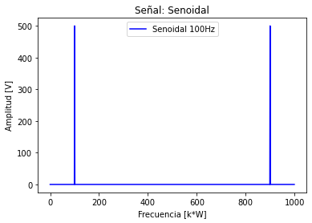

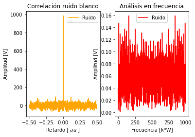

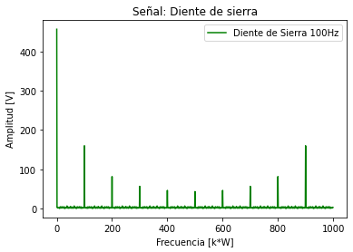

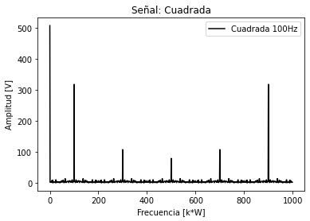

```python
# Senoidal 3Hz
t1,f1 = mySignalGenerator ('sin',(100, 1) ,fs, N, (0, 0));
k1, Fk1 = mi_analizador(f1, N);
# Ruido
t2,f2 = mySignalGenerator ('n',(0, 1) ,fs, N, (0, 0));
k2, Fk2 = mi_analizador(f2, N);
# Diente de Sierra 3Hz
t3,f3 = mySignalGenerator ('t',(1/100, 1) ,fs, N, (0, 0));
k3, Fk3 = mi_analizador(f3, N);
# Cuadrada 3Hz
t4,f4 = mySignalGenerator ('sq',(1/100, 1) ,fs, N, (0, 0));
k4, Fk4 = mi_analizador(f4, N);

# Plot
fig, ax1 = plt.subplots(1,1)
ax1.plot(k1*W, np.abs(Fk1), label='Senoidal 100Hz', color='b')
ax1.set_xlabel('Frecuencia [k*W]')
ax1.set_ylabel('Amplitud [V]')
ax1.set_title("Señal: Senoidal")
ax1.legend()

fig, (ax5,ax2) = plt.subplots(1,2)
ax5.plot(t2 - N/(2*fs), np.correlate(f2,f2,'same'), label='Ruido', color='orange')  #Hay que escalar esto.
ax5.set_xlabel('Retardo [ $\tau$ ]')
ax5.set_ylabel('Amplitud [V]')
ax5.set_title("Correlación ruido blanco")
ax5.legend()

ax2.plot(k2*W, np.abs(Fk2 * 2/N), label='Ruido', color='r')  #Hay que escalar esto.
ax2.set_xlabel('Frecuencia [k*W]')
ax2.set_ylabel('Amplitud [V]')  #Debería ser sigma^2/N porque el area en t es sigma^2 y la base es N.
ax2.set_title("Análisis en frecuencia")
ax2.legend()






fig, ax3 = plt.subplots(1,1)
ax3.plot(k3*W, np.abs(Fk3), label='Diente de Sierra 100Hz', color='g')
ax3.set_xlabel('Frecuencia [k*W]')
ax3.set_ylabel('Amplitud [V]')
ax3.set_title("Señal: Diente de sierra")
ax3.legend()

fig, ax4 = plt.subplots(1,1)
ax4.plot(k4*W, np.abs(Fk4), label='Cuadrada 100Hz', color='k')
ax4.set_xlabel('Frecuencia [k*W]')
ax4.set_ylabel('Amplitud [V]')
ax4.set_title("Señal: Cuadrada")
ax4.legend()
```

**2.b)** (Opcional) Compare el tiempo de ejecución de la DFT implementada en con la **FFT** (implementada en **scipy.signal**) en función del tamaño de la señal N. Grafique el tiempo de ejecución de ambos casos en función de N.

**Ayuda:** Utilice el módulo **timeit** para medir el tiempo transcurrido.

```python
import timeit

the_start = timeit.timeit()
print("hello")
the_end = timeit.timeit()
print(the_start - the_end)
```

```
hello
-0.004245300000093266
```

**¡Atención!:** Completá la siguiente tabla. Podés guardar tus resultados en la lista **tus_resultados**.

```python
from pandas import DataFrame
from IPython.display import HTML

#######################################
# Tu simulación que genere resultados #
#######################################

tus_resultados = [ ['--'],
                   [''], # <-- acá debería haber numeritos :)
                   [''], # <-- acá debería haber numeritos :)
                   [''], # <-- acá debería haber numeritos :)
                   [''], # <-- acá debería haber numeritos :)
                   [''], # <-- acá debería haber numeritos :)
                   [''], # <-- acá debería haber numeritos :)
                   [''], # <-- acá debería haber numeritos :)
                   ['']  # <-- acá debería haber numeritos :)
                 ]
df = DataFrame(tus_resultados, columns=['tiempo transcurrido (s)'],
               index=['Tamaño de la señal N',
                      16,
                      32,
                      64,
                      128,
                      256,
                      512,
                      1024,
                      2048
                     ])
HTML(df.to_html())
```

[output not shown]

**3.a)** Verifique el efecto del leakage para una senoidal de $f_0 = f_S/4 + f_D$ siendo $f_D = (0.01,\, 0.25,\, 0.5)$, es decir una frecuencia de desintonía respecto al bin $f_S/4$.

**¡Atención!:** Completá la siguiente tabla. Podés guardar tus resultados en la lista **tus_resultados**.

```python
#######################################
# Tu simulación que genere resultados #
#######################################

tus_resultados = [ ['$ \lvert X(f_0) \lvert$', '$ \lvert X(f_0+1) \lvert $', '$\sum_{i=F} \lvert X(f_i) \lvert ^2 $'],
                   ['',                        '',                           '$F:f \neq f_0$'],
                  ['', '', ''], # <-- acá debería haber numeritos :)
                  ['', '', ''], # <-- acá debería haber numeritos :)
                  ['', '', ''], # <-- acá debería haber numeritos :)
                  ['', '', '']  # <-- acá debería haber numeritos :)
                 ]
df = DataFrame(tus_resultados, columns=['Frecuencia central', 'Primer adyacente', 'Resto de frecuencias'],
               index=['$f_0$ \ expr. matemática',
                      '',
                      '$f_S/4$',
                      '$f_S/4+0.01$',
                      '$f_S/4+0.25$',
                      '$f_S/4+0.5$'])
HTML(df.to_html())
```

|  | Frecuencia central | Primer adyacente | Resto de frecuencias |
| --- | --- | --- | --- |
| $f_0$ \ expr. matemática | $ \lvert X(f_0) \lvert$ | $ \lvert X(f_0+1) \lvert $ | $\sum_{i=F} \lvert X(f_i) \lvert ^2 $ |
|  |  |  | $F:f \neq f_0$ |
| $f_S/4$ |  |  |  |
| $f_S/4+0.01$ |  |  |  |
| $f_S/4+0.25$ |  |  |  |
| $f_S/4+0.5$ |  |  |  |

**3.b)** Verifique qué ocurre si a la señal de $f_0 = f_S/4 + 0.5$ se le agregan ceros para prolongar su duración. Es decir si la señal tiene N muestras, agregue $M_j$ ceros siendo $M_j = ( \frac{N}{10},\, N,\, 10N)$.

```python
# Inserte aquí su código
```

[output not shown]

**3.c)** ¿Ha variado la resolución espectral en los casos de 3.b?

**3.d)** ¿Cuál es el efecto que se produce en cada caso? Esta técnica se conoce como Zero padding.

**3.e)** Analice cuál es la frecuencia $\hat{f}_0 = \mathop{arg\ max}_f \{\lvert X(f) \rvert \}$ a la que ocurre el máximo del espectro y en cuánto difiere de $f_0$ en términos porcentuales.

```python
#######################################
# Tu simulación que genere resultados #
#######################################

tus_resultados = ['', # <-- acá debería haber numeritos :)
                  '', # <-- acá debería haber numeritos :)
                  '', # <-- acá debería haber numeritos :)
                  '' # <-- acá debería haber numeritos :)
                 ]
df = DataFrame(tus_resultados, columns=['$e_\%$'],
               index=['0',
                      '$N/10$',
                      '$N$',
                      '$10N$'])
HTML(df.to_html())
```

|  | $e_\%$ |
| --- | --- |
| 0 |  |
| $N/10$ |  |
| $N$ |  |
| $10N$ |  |

**4)** Para cada señal propuesta complete los valores que se indican en las siguientes consignas.

- En la tabla de resultados de cada inciso, en la fila indicada con **predicción** responda conceptualmente qué contenido espectral debería obtener tras evaluar su FFT (sin realizar ninguna simulación).
- Calcule su espectro y discuta la predicción con los resultados obtenidos de la **simulación**. Intente discutir las diferencias si las hubiera en las respuestas de cada inciso.
- Preste especial atención en su discusión a:
  - La energía total de la señal
  - La energía del tono en particular
  - La localización del tono en el espectro
- Siga las indicaciones particulares para cada señal.

**Ayuda:** Las siguientes señales pueden generarse a partir de una senoidal *patrón* siguiendo las consignas de la derecha.

|  | 4.a) Senoidal de **energía normalizada** y frecuencia $f_0 = 9 \cdot f_S/N$. |
| --- | --- |

```python
#######################################
# Tu simulación que genere resultados #
#######################################

tus_resultados = [ ['$\sum_{f=0}^{f_S/2} \lvert X(f) \rvert ^2$', '$ \lvert X(f_0) \rvert ^2 $', '$ \mathop{arg\ max}_f \{\lvert X(f) \rvert ^2\} $'],
                   ['',                                     '',                           '$f \in [0:f_S/2]$'],
                  ['', '', ''],
                  ['', '', ''], # <-- completar acá
                  ['', '', ''],
                  ['', '', '']  # <-- completar acá
                 ]
df = DataFrame(tus_resultados, columns=['Energía total', 'Energía en $f_0$', 'Máximo de Energía'],
               index=['$f_0$ \ expr. matemática',
                      '',
                      '',
                      'predicción',
                      '',
                      'simulación'])
HTML(df.to_html())
```

|  | Energía total | Energía en $f_0$ | Máximo de Energía |
| --- | --- | --- | --- |
| $f_0$ \ expr. matemática | $\sum_{f=0}^{f_S/2} \lvert X(f) \rvert ^2$ | $ \lvert X(f_0) \rvert ^2 $ | $ \mathop{arg\ max}_f \{\lvert X(f) \rvert ^2\} $ |
|  |  |  | $f \in [0:f_S/2]$ |
| predicción |  |  |  |
| simulación |  |  |  |

|  | 4.b) **1 solo ciclo** de la misma senoidal de **energía normalizada** y frecuencia $f_0 = 9 \cdot f_S/N$. |
| --- | --- |

```python
#######################################
# Tu simulación que genere resultados #
#######################################

tus_resultados = [ ['$\sum_{f=0}^{f_S/2} \lvert X(f) \rvert ^2$', '$ \lvert X(f_0) \rvert ^2 $', '$ \mathop{arg\ max}_f \{\lvert X(f) \rvert ^2\} $'],
                   ['',                                     '',                           '$f \in [0:f_S/2]$'],
                  ['', '', ''],
                  ['', '', ''], # <-- completar acá
                  ['', '', ''],
                  ['', '', '']  # <-- completar acá
                 ]
df = DataFrame(tus_resultados, columns=['Energía total', 'Energía en $f_0$', 'Máximo de Energía'],
               index=['$f_0$ \ expr. matemática',
                      '',
                      '',
                      'predicción',
                      '',
                      'simulación'])
HTML(df.to_html())
```

|  | Energía total | Energía en $f_0$ | Máximo de Energía |
| --- | --- | --- | --- |
| $f_0$ \ expr. matemática | $\sum_{f=0}^{f_S/2} \lvert X(f) \rvert ^2$ | $ \lvert X(f_0) \rvert ^2 $ | $ \mathop{arg\ max}_f \{\lvert X(f) \rvert ^2\} $ |
|  |  |  | $f \in [0:f_S/2]$ |
| predicción |  |  |  |
| simulación |  |  |  |

Observe el resultado y compare sus resultados con el punto anterior. ¿Qué ha cambiado? ¿Cuánto vale la energía de un solo ciclo de senoidal respecto al caso anterior?

|  | 4.c) 1 solo ciclo de la misma senoidal de energía normalizada y frecuencia $f_0 = 9 \cdot f_S/N$ **pero demorado un tiempo igual a dos ciclos**. |
| --- | --- |

```python
#######################################
# Tu simulación que genere resultados #
#######################################

tus_resultados = [ ['$\sum_{f=0}^{f_S/2} \lvert X(f) \rvert ^2$', '$ \lvert X(f_0) \rvert ^2 $', '$ \mathop{arg\ max}_f \{\lvert X(f) \rvert ^2\} $'],
                   ['',                                     '',                           '$f \in [0:f_S/2]$'],
                  ['', '', ''],
                  ['', '', ''], # <-- completar acá
                  ['', '', ''],
                  ['', '', '']  # <-- completar acá
                 ]
df = DataFrame(tus_resultados, columns=['Energía total', 'Energía en $f_0$', 'Máximo de Energía'],
               index=['$f_0$ \ expr. matemática',
                      '',
                      '',
                      'predicción',
                      '',
                      'simulación'])
HTML(df.to_html())
```

|  | Energía total | Energía en $f_0$ | Máximo de Energía |
| --- | --- | --- | --- |
| $f_0$ \ expr. matemática | $\sum_{f=0}^{f_S/2} \lvert X(f) \rvert ^2$ | $ \lvert X(f_0) \rvert ^2 $ | $ \mathop{arg\ max}_f \{\lvert X(f) \rvert ^2\} $ |
|  |  |  | $f \in [0:f_S/2]$ |
| predicción |  |  |  |
| simulación |  |  |  |

En este caso, ¿Qué ha cambiado respecto al anterior? ¿Cómo se manifiesta en el dominio frecuencial?

[output not shown]

```python
#######################################
# Tu simulación que genere resultados #
#######################################

tus_resultados = [ ['$\sum_{f=0}^{f_S/2} \lvert X(f) \rvert ^2$', '$ \lvert X(f_0) \rvert ^2 $', '$ \mathop{arg\ max}_f \{\lvert X(f) \rvert ^2\} $'],
                   ['',                                     '',                           '$f \in [0:f_S/2]$'],
                  ['', '', ''],
                  ['', '', ''], # <-- completar acá
                  ['', '', ''],
                  ['', '', '']  # <-- completar acá
                 ]
df = DataFrame(tus_resultados, columns=['Energía total', 'Energía en $f_0$', 'Máximo de Energía'],
               index=['$f_0$ \ expr. matemática',
                      '',
                      '',
                      'predicción',
                      '',
                      'simulación'])
HTML(df.to_html())
```

|  | Energía total | Energía en $f_0$ | Máximo de Energía |
| --- | --- | --- | --- |
| $f_0$ \ expr. matemática | $\sum_{f=0}^{f_S/2} \lvert X(f) \rvert ^2$ | $ \lvert X(f_0) \rvert ^2 $ | $ \mathop{arg\ max}_f \{\lvert X(f) \rvert ^2\} $ |
|  |  |  | $f \in [0:f_S/2]$ |
| predicción |  |  |  |
| simulación |  |  |  |

¿Puede localizar ambas componentes en este espectro? ¿Cómo lo haría?

|  | 4.e) Idéntico al caso anterior salvo que se invierte la ocurrencia de las señales. |
| --- | --- |

```python
#######################################
# Tu simulación que genere resultados #
#######################################

tus_resultados = [ ['$\sum_{f=0}^{f_S/2} \lvert X(f) \rvert ^2$', '$ \lvert X(f_0) \rvert ^2 $', '$ \mathop{arg\ max}_f \{\lvert X(f) \rvert ^2\} $'],
                   ['',                                     '',                           '$f \in [0:f_S/2]$'],
                  ['', '', ''],
                  ['', '', ''], # <-- completar acá
                  ['', '', ''],
                  ['', '', '']  # <-- completar acá
                 ]
df = DataFrame(tus_resultados, columns=['Energía total', 'Energía en $f_0$', 'Máximo de Energía'],
               index=['$f_0$ \ expr. matemática',
                      '',
                      '',
                      'predicción',
                      '',
                      'simulación'])
HTML(df.to_html())
```

|  | Energía total | Energía en $f_0$ | Máximo de Energía |
| --- | --- | --- | --- |
| $f_0$ \ expr. matemática | $\sum_{f=0}^{f_S/2} \lvert X(f) \rvert ^2$ | $ \lvert X(f_0) \rvert ^2 $ | $ \mathop{arg\ max}_f \{\lvert X(f) \rvert ^2\} $ |
|  |  |  | $f \in [0:f_S/2]$ |
| predicción |  |  |  |
| simulación |  |  |  |

¿ha cambiado el espectro respecto al caso anterior? ¿Si solo dispone del espectro, puede decir cuál ha ocurrido antes? ¿Resulta útil el análisis de espectral mediante la transformada de Fourier en este caso?

[output not shown]

```python
#######################################
# Tu simulación que genere resultados #
#######################################

tus_resultados = [ ['$\sum_{f=0}^{f_S/2} \lvert X(f) \rvert ^2$', '$ \lvert X(f_0) \rvert ^2 $', '$ \mathop{arg\ max}_f \{\lvert X(f) \rvert ^2\} $'],
                   ['',                                     '',                           '$f \in [0:f_S/2]$'],
                  ['', '', ''],
                  ['', '', ''], # <-- completar acá
                  ['', '', ''],
                  ['', '', '']  # <-- completar acá
                 ]
df = DataFrame(tus_resultados, columns=['Energía total', 'Energía en $f_0$', 'Máximo de Energía'],
               index=['$f_0$ \ expr. matemática',
                      '',
                      '',
                      'predicción',
                      '',
                      'simulación'])
HTML(df.to_html())
```

|  | Energía total | Energía en $f_0$ | Máximo de Energía |
| --- | --- | --- | --- |
| $f_0$ \ expr. matemática | $\sum_{f=0}^{f_S/2} \lvert X(f) \rvert ^2$ | $ \lvert X(f_0) \rvert ^2 $ | $ \mathop{arg\ max}_f \{\lvert X(f) \rvert ^2\} $ |
|  |  |  | $f \in [0:f_S/2]$ |
| predicción |  |  |  |
| simulación |  |  |  |

¿Qué energía tiene la componente $f_0$ en el espectro en comparación con la señal donde los 9 ciclos estaban presentes? ¿Y respecto a la que solo había 1 ciclo?

|  | 4.g) Idem anterior, pero cada ciclo con amplitudes (1, 5, 3). |
| --- | --- |

```python
#######################################
# Tu simulación que genere resultados #
#######################################

tus_resultados = [ ['$\sum_{f=0}^{f_S/2} \lvert X(f) \rvert ^2$', '$ \lvert X(f_0) \rvert ^2 $', '$ \mathop{arg\ max}_f \{\lvert X(f) \rvert ^2\} $'],
                   ['',                                     '',                           '$f \in [0:f_S/2]$'],
                  ['', '', ''],
                  ['', '', ''], # <-- completar acá
                  ['', '', ''],
                  ['', '', '']  # <-- completar acá
                 ]
df = DataFrame(tus_resultados, columns=['Energía total', 'Energía en $f_0$', 'Máximo de Energía'],
               index=['$f_0$ \ expr. matemática',
                      '',
                      '',
                      'predicción',
                      '',
                      'simulación'])
HTML(df.to_html())
```

|  | Energía total | Energía en $f_0$ | Máximo de Energía |
| --- | --- | --- | --- |
| $f_0$ \ expr. matemática | $\sum_{f=0}^{f_S/2} \lvert X(f) \rvert ^2$ | $ \lvert X(f_0) \rvert ^2 $ | $ \mathop{arg\ max}_f \{\lvert X(f) \rvert ^2\} $ |
|  |  |  | $f \in [0:f_S/2]$ |
| predicción |  |  |  |
| simulación |  |  |  |

¿Qué energía tiene la componente $f_0$ en el espectro en comparación con el inciso anterior?

|  | 4.h) Idem patrón anterior, pero repetido 3 veces. |
| --- | --- |

```python
#######################################
# Tu simulación que genere resultados #
#######################################

tus_resultados = [ ['$\sum_{f=0}^{f_S/2} \lvert X(f) \rvert ^2$', '$ \lvert X(f_0) \rvert ^2 $', '$ \mathop{arg\ max}_f \{\lvert X(f) \rvert ^2\} $'],
                   ['',                                     '',                           '$f \in [0:f_S/2]$'],
                  ['', '', ''],
                  ['', '', ''], # <-- completar acá
                  ['', '', ''],
                  ['', '', '']  # <-- completar acá
                 ]
df = DataFrame(tus_resultados, columns=['Energía total', 'Energía en $f_0$', 'Máximo de Energía'],
               index=['$f_0$ \ expr. matemática',
                      '',
                      '',
                      'predicción',
                      '',
                      'simulación'])
HTML(df.to_html())
```

|  | Energía total | Energía en $f_0$ | Máximo de Energía |
| --- | --- | --- | --- |
| $f_0$ \ expr. matemática | $\sum_{f=0}^{f_S/2} \lvert X(f) \rvert ^2$ | $ \lvert X(f_0) \rvert ^2 $ | $ \mathop{arg\ max}_f \{\lvert X(f) \rvert ^2\} $ |
|  |  |  | $f \in [0:f_S/2]$ |
| predicción |  |  |  |
| simulación |  |  |  |

¿Qué energía tiene la componente $f_0$ en el espectro en comparación con el inciso anterior? ¿Y respecto al que estaban los 9 ciclos presentes pero con la misma amplitud?

|  | 4.i) En este caso genere un ciclo de $f_0 = 9 \cdot f_S/N$, y seguido otro ciclo pero desfasado $\pi$ radianes. |
| --- | --- |

```python
#######################################
# Tu simulación que genere resultados #
#######################################

tus_resultados = [ ['$\sum_{f=0}^{f_S/2} \lvert X(f) \rvert ^2$', '$ \lvert X(f_0) \rvert ^2 $', '$ \mathop{arg\ max}_f \{\lvert X(f) \rvert ^2\} $'],
                   ['',                                     '',                           '$f \in [0:f_S/2]$'],
                  ['', '', ''],
                  ['', '', ''], # <-- completar acá
                  ['', '', ''],
                  ['', '', '']  # <-- completar acá
                 ]
df = DataFrame(tus_resultados, columns=['Energía total', 'Energía en $f_0$', 'Máximo de Energía'],
               index=['$f_0$ \ expr. matemática',
                      '',
                      '',
                      'predicción',
                      '',
                      'simulación'])
HTML(df.to_html())
```

|  | Energía total | Energía en $f_0$ | Máximo de Energía |
| --- | --- | --- | --- |
| $f_0$ \ expr. matemática | $\sum_{f=0}^{f_S/2} \lvert X(f) \rvert ^2$ | $ \lvert X(f_0) \rvert ^2 $ | $ \mathop{arg\ max}_f \{\lvert X(f) \rvert ^2\} $ |
|  |  |  | $f \in [0:f_S/2]$ |
| predicción |  |  |  |
| simulación |  |  |  |

¿Qué energía tiene la componente $f_0$ en el espectro en comparación con el que estaba un solo ciclo presente?

Luego de realizar la experimentación y observando los resultados obtenidos discuta si es fiable o no medir en el dominio de Fourier, por medio de la FFT los siguientes aspectos de una señal:

```
• Energía
• Contenido espectral
• Energía de un determinado ancho de banda o componente espectral
• Localización temporal de un determinado componente espectral.
```

**5)** Simule el efecto de cuantizar una señal continua en el tiempo mediante un conversor analógico digital (ADC).

Para ello analice señales determinísticas, por ejemplo una senoidal de **energía normalizada** y frecuencia $f_0$, y otras que varíen de forma más aleatoria y por lo tanto, representativa de una señal real, por ejemplo añadiendo ruido. Es decir que la señal *real* simulada será

$$s_R = s + n$$

donde la señal $n$ debe tener una energía de $1/10$.

Puede simular una señal continua (aproximadamente para los fines prácticos), mediante una señal muestreada a una $f^1_S$ muy alta en comparación con las $f_S$ que quiere estudiar, y un tipo de dato de doble precisión (double o float de 64 bits). De esta manera se asegura una grilla de cuantización (en tiempo y amplitud) mucho más densa que la que se va a simular. Se pide cuantizar a palabras de 4, 8 y 16 bits, obteniendo

$$ s_Q = \mathop{Q}_i \{s_R\} \quad i \in (4, 8, 16) $$

Siendo $\mathop{Q}_i$ la función **no lineal** responsable de la cuantización a *i-* bits de la señal real $s_R$. Describa el ruido de cuantización

$$ e = s_Q - s_R$$

para las 3 situaciones antedichas siguiendo las siguientes consignas.

**5.a)** La señal temporal $e$ y su espectro $E$.

```python
#######################################
# Tu simulación que genere resultados #
#######################################

tus_resultados = [ ['$\sum_{f=0}^{f_S/2} \lvert S_R(f) \rvert ^2$', '$\sum_{f=0}^{f_S/2} \lvert S_Q(f) \rvert ^2$', '$\sum_{f=0}^{f_S/2} \lvert e(f) \rvert ^2$' ],
                   ['',                                             '',                                             ''                              ],
                   ['', '', ''], # <-- completar acá
                   ['', '', ''], # <-- completar acá
                   ['', '', ''], # <-- completar acá
                 ]
df = DataFrame(tus_resultados, columns=['Energía total', 'Energía total Q', 'Energía total $e$'],
               index=['$f_0$ \ expr. matemática',
                      '',
                      '4 bits',
                      '8 bits',
                      '16 bits'
                      ])
HTML(df.to_html())
```

|  | Energía total | Energía total Q | Energía total $e$ |
| --- | --- | --- | --- |
| $f_0$ \ expr. matemática | $\sum_{f=0}^{f_S/2} \lvert S_R(f) \rvert ^2$ | $\sum_{f=0}^{f_S/2} \lvert S_Q(f) \rvert ^2$ | $\sum_{f=0}^{f_S/2} \lvert e(f) \rvert ^2$ |
| 4 bits |  |  |  |
| 8 bits |  |  |  |
| 16 bits |  |  |  |

**5.b)** El histograma de la señal $e_i$ para cada tamaño de palabra.

```python
#####################################
# Tu simulación que genere gráficas #
#####################################
```

¿Qué información podemos obtener de esta forma de analizar la señal $e_i$?

**5.c)** Una descripción de la señal $e_i$, por medio del **valor medio**, su valor **RMS** y su energía **energía**

```python
#######################################
# Tu simulación que genere resultados #
#######################################

tus_resultados = [
                   ['', '', ''], # <-- completar acá
                   ['', '', ''], # <-- completar acá
                   ['', '', ''], # <-- completar acá
                 ]
df = DataFrame(tus_resultados, columns=['Valor medio', 'RMS', 'Energía'],
               index=[
                      '4 bits',
                      '8 bits',
                      '16 bits'
                      ])
HTML(df.to_html())
```

|  | Valor medio | RMS | Energía |
| --- | --- | --- | --- |
| 4 bits |  |  |  |
| 8 bits |  |  |  |
| 16 bits |  |  |  |

**5.d)** Una descripción **estadística** de la señal $e_i$, por medio de su **media**, su **desvío estándard** y su energía **varianza**.

```python
#######################################
# Tu simulación que genere resultados #
#######################################

tus_resultados = [
                   ['', '', ''], # <-- completar acá
                   ['', '', ''], # <-- completar acá
                   ['', '', ''], # <-- completar acá
                 ]
df = DataFrame(tus_resultados, columns=['Media', 'Desvío estándard', 'Varianza'],
               index=[
                      '4 bits',
                      '8 bits',
                      '16 bits'
                      ])
HTML(df.to_html())
```

|  | Media | Desvío estándard | Varianza |
| --- | --- | --- | --- |
| 4 bits |  |  |  |
| 8 bits |  |  |  |
| 16 bits |  |  |  |

Discutir las similitudes y diferencias con los parámetros calculados en **c)** y **d)**.